# Insurance with R

## 1. Dataförståelse

**Läs in data:**

```r
# message och warning=FALSE, så undviks output av följande:
library(tidyverse)
df <- read_csv("insurance_costs.csv")
```

```r
glimpse(df)
```

```
## Rows: 1,100
## Columns: 14
## $ customer_id       <chr> "C100000", "C100001", "C100002", "C100003", "C100004…
## $ age               <dbl> 48, 40, 50, 62, 39, 39, 63, 52, 36, 49, 36, 36, 45, …
## $ sex               <chr> "female", "male", "female", "male", "female", "femal…
## $ region            <chr> "east", "west", "south", "north", "east", "west", "e…
## $ bmi               <dbl> 24.8, 29.5, 18.3, 25.5, 27.3, 23.3, 23.9, 24.8, 28.6…
## $ children          <dbl> 0, 1, 2, 5, 2, 4, 3, 2, 0, 2, 2, 2, 1, 1, 1, 1, 0, 3…
## $ smoker            <chr> "no", "no", "no", "yes", "no", "no", "no", "no", "no…
## $ chronic_condition <chr> "no", "no", "no", "no", "no", "no", "no", "no", "yes…
## $ exercise_level    <chr> "high", "medium", "high", "medium", "medium", "high"…
## $ plan_type         <chr> "basic", "basic", "standard", "basic", "basic", "sta…
## $ prior_accidents   <dbl> 0, 0, 0, 0, 0, 0, 0, 0, 0, 1, 0, 1, 0, 0, 0, 0, 0, 0…
## $ prior_claims      <dbl> 0, 1, 0, 0, 1, 0, 0, 0, 1, 0, 0, 1, 0, 1, 3, 0, 0, 0…
## $ annual_checkups   <dbl> 1, 4, 3, NA, 0, 2, 1, 2, 3, 2, 3, 3, 4, 4, 2, 1, 2, …
## $ charges           <dbl> 6439.10, 8274.06, 5190.99, 14500.35, 6534.40, 8026.3…
```

Det är 1,100 observationer med 14 variabler, och datatyperna ska justeras:

- heltal, decimaltal, booleans och strängar.
- det kan behövas filtrering eller ifyllnad, samt trim, lower, och title.

**Se närmare på kolumner med saknade värden:**

```r
# Antal NA per kolumn:
# colSums(is.na(df_clean))
#     anger att: bmi, exercise_level, annual_checkups har NaN.

# Se över unique values i olika kolumner:
# unique(df$exercise_level)
unique(df$plan_type)
```

```
## [1] "basic"    "standard" "premium"  "Premium"  "Standard"
```

## 2. Datastädning och förberedelse

**Åtgärder i städning:**

- Kundnummer görs till heltal genom att först ta bort “C”.
- Vid NaN: BMI och årliga besök får median insatt, och träningsnivå får `unknown`.
- Gör “Ja/Nej” till logisk.

```r
source("script1_cleaning.R")
```

**Nya variabler och konvertera *chr* till *fct*:**

- Skapa kolumner med *if_else* och *case_when* som följer kriterier, så fås olika grupper. Även `historic_score` via addition av tidigare olyckor samt fordringar.
- Det görs även en lista med kategoriska kolumner (som är städade redan), sen en funktion som sätter *as.factor*, sen kallas den och skriver över resultatet till `df_clean`.

```r
# Summary visar vanliga värden, så kan man välja numeriska gränser i kategori variabler.
# summary(df_clean$bmi)
source("script2_createVar_andFactor.R")
glimpse(df_clean)
```

```
## Rows: 1,100
## Columns: 19
## $ customer_id       <int> 100000, 100001, 100002, 100003, 100004, 100005, 1000…
## $ age               <int> 48, 40, 50, 62, 39, 39, 63, 52, 36, 49, 36, 36, 45, …
## $ sex               <fct> female, male, female, male, female, female, female, …
## $ region            <fct> East, West, South, North, East, West, East, North, E…
## $ bmi               <dbl> 24.8, 29.5, 18.3, 25.5, 27.3, 23.3, 23.9, 24.8, 28.6…
## $ children          <int> 0, 1, 2, 5, 2, 4, 3, 2, 0, 2, 2, 2, 1, 1, 1, 1, 0, 3…
## $ smoker            <lgl> FALSE, FALSE, FALSE, TRUE, FALSE, FALSE, FALSE, FALS…
## $ chronic_condition <lgl> FALSE, FALSE, FALSE, FALSE, FALSE, FALSE, FALSE, FAL…
## $ exercise_level    <fct> High, Medium, High, Medium, Medium, High, High, Medi…
## $ plan_type         <fct> Basic, Basic, Standard, Basic, Basic, Standard, Basi…
## $ prior_accidents   <int> 0, 0, 0, 0, 0, 0, 0, 0, 0, 1, 0, 1, 0, 0, 0, 0, 0, 0…
## $ prior_claims      <int> 0, 1, 0, 0, 1, 0, 0, 0, 1, 0, 0, 1, 0, 1, 3, 0, 0, 0…
## $ annual_checkups   <int> 1, 4, 3, 2, 0, 2, 1, 2, 3, 2, 3, 3, 4, 4, 2, 1, 2, 1…
## $ charges           <dbl> 6439.10, 8274.06, 5190.99, 14500.35, 6534.40, 8026.3…
## $ bmi_class         <fct> Normal, Overweight, Underweight, Normal, Overweight,…
## $ historic_score    <int> 0, 1, 0, 0, 1, 0, 0, 0, 1, 1, 0, 2, 0, 1, 3, 0, 0, 0…
## $ risk_level        <fct> Low, Low, Low, High, Low, Low, Low, Low, High, High,…
## $ age_group         <fct> Middle Age, Young Adult, Middle Age, Senior, Young A…
## $ exercises_checks  <fct> Healthy, Less Healthy, Healthy, Less Healthy, Less H…
```

Nu har vi factor som datatyp för kategorier, så *dplyr* hanterar grupperingar väl.

De nya variablerna `bmi_class`, `historic_score`, `risk_level`, `age_group`, `exercise_checks` ger regressionsmodellering yta att undersöka om olika profiler är kopplade till större betalning.

## 3. Beskrivande analys

### 3.1 Betalning bland åldergrupper

```r
# Ladda script 3 och visa output för åldergrupper
source("script3_descriptive_analysis.R")
age_grouped # stigande ordning: medelvärde.
```

```
## # A tibble: 4 × 5
##   age_group   mean_charge median_charge     n proportion_pct
##   <fct>             <dbl>         <dbl> <int>          <dbl>
## 1 Junior            8337.         7884.    44            4
## 2 Young Adult       9076.         8103.   432           39.3
## 3 Middle Age       10550.         9758.   527           47.9
## 4 Senior           12566.        11166.    97            8.8
```

De flesta är inte äldre än 60 eller yngre än 20. Även syns att betalningar ökar i snitt och median med ålder.

### 3.2 Betalning bland bmi-kategori

```r
bmi_grouped # stigande (mean)
```

```
## # A tibble: 4 × 5
##   bmi_class   mean_charge median_charge std_charge proportion_pct
##   <fct>             <dbl>         <dbl>      <dbl>          <dbl>
## 1 Underweight       9171.         8286.      4427.           22.9
## 2 Normal            9854.         8896.      4484.           22.6
## 3 Overweight       10139.         9168.      4337.           29.9
## 4 Obese            10985.         9910.      4907.           24.5
```

De med mer än 30.5 och mindre än 16 i bmi betalar mer och mindre, respektivt, än normal- och överviktiga. En föraning är att kostnader har större skillnader för de två mitten bmi-klasserna (och ålder) med ursprung i andra led. Övergripande stiger kostnader med bmi-klass.

### 3.3 Betalning inom rökning

```r
smoker_grouped # fallande (mean)
```

```
## # A tibble: 2 × 4
##   smoker mean_charge median_charge proportion_pct
##   <lgl>        <dbl>         <dbl>          <dbl>
## 1 TRUE        16537.        16392.           18.5
## 2 FALSE        8586.         8232.           81.5
```

Rökare betalar det dubbla, medan de motsvarar 18.5%.

### 3.4 Betalning bland rökare och kroniska

```r
smoker_chronic # fallande (proportion)
```

```
## # A tibble: 4 × 6
##   smoker chronic_condition mean_charge median_charge std_charge proportion_pct
##   <lgl>  <lgl>                   <dbl>         <dbl>      <dbl>          <dbl>
## 1 FALSE  FALSE                   7554.         7467.      2569.           62.5
## 2 FALSE  TRUE                   11978.        11871.      3046.           19
## 3 TRUE   FALSE                  15444.        14652.      3411.           13.2
## 4 TRUE   TRUE                   19224.        18883.      3282.            5.4
```

Medan nästan 63% varken är kroniska eller rökare, indikeras stigande kostnader (medel) för drabbade från cirka 7500 till 19200.

### 3.5 Visualer

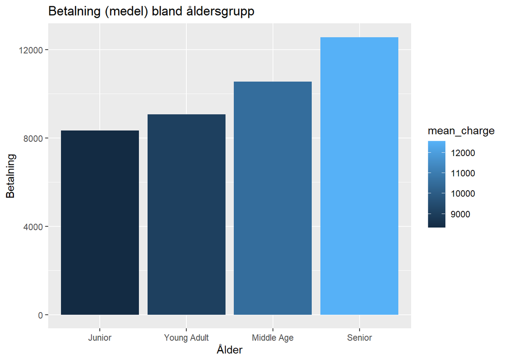

```r
source("script4_visuals.R")
# åldersgrupp col plot
ageplot
```

Betalning tycks öka med åldersgrupp, särskilt när senior.

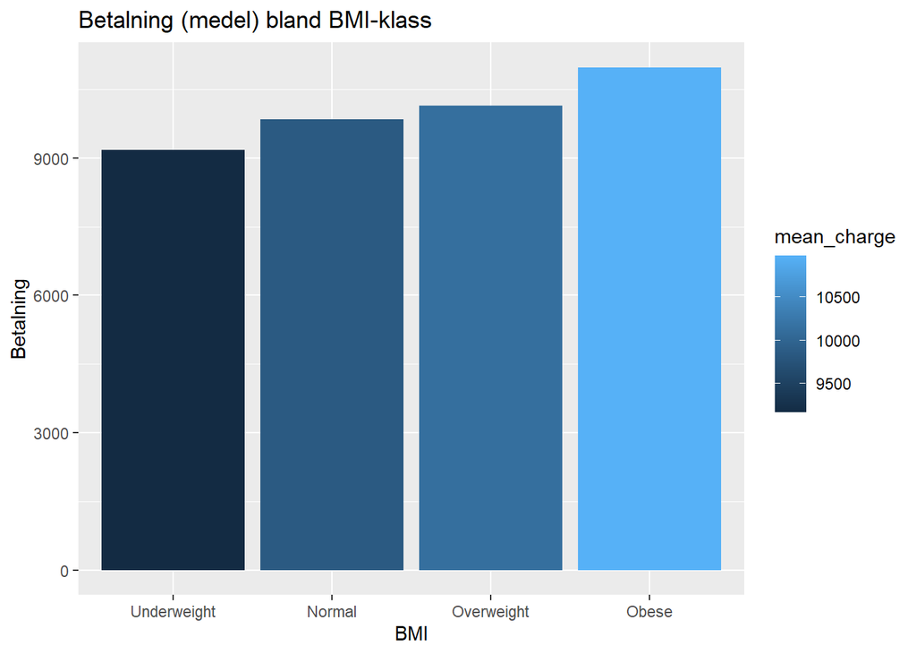

```r
# bmi-klasser col plot
bmiplot
```

Betalning tycks öka med bmi-klass, men de två i mitten betalar nästan lika.

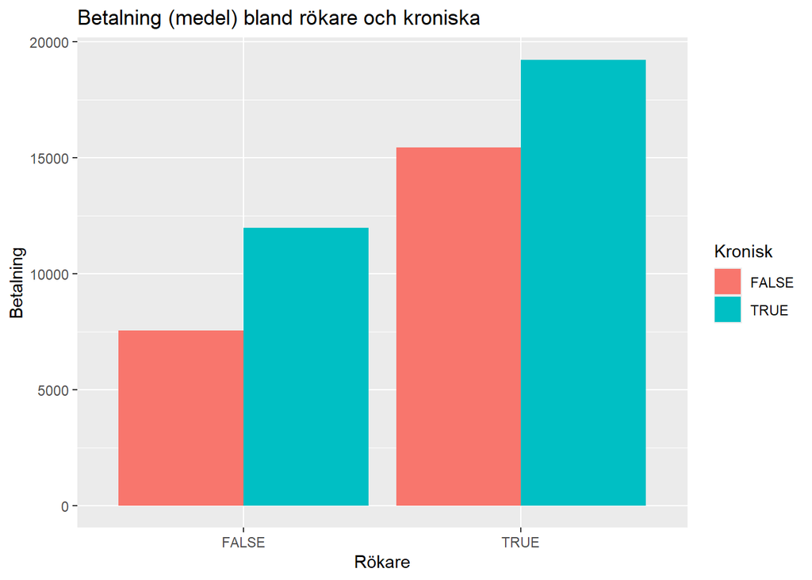

```r
# true/false col plot
smoke_chron_plot
```

Bland rökare, betalar kroniska mera, samma gäller icke-rökare. Samtidigt är rökande status led till högre betalning också. Är profilen ej rökande eller kronisk så betalar denna ungefär hälften eller en tredjedel av de andra profilerna.

I helhet tycks ålder eller vikt inte driva skillnader i betalning mest, utan övriga faktorer såsom rökare och kroniska, där differenser i pris är framstående. Vad som antyds är att rökning är en kritisk risk som bör rättfärdiga en högre försäkringskostnad. Rökning och övriga faktorer gås igenom i regressionsanalysen.

## 4. Regressionsanalys

Vilka features som leder mest till prissättningarna ska nu fokuseras på. I initiell analys syntes liknelser och skillnader emellan profiler, men helheten i sambanden är inte klarlagt. Är det så att risker går upp i steg som från vuxen till senior, eller numeriskt (kontinuerligt); jämförelse av olikt designade regressionsmodeller följer, efter ett inledande hypotestest.

### 4.1 Hypotestest

Om binära och numeriska variabler har stor påverkan på pris var för sig, så kan p-värde och konfidensintervall indikera viktigheten i tvåsticksprov Welch t-test. ANOVA hanterar ickebinära och görs inte i detta arbetet. T-testets isolerande prövning blir uppföljt av multipel regression efteråt vilket fångar variablernas samspel.

```r
# Välj rökare, kroniska, hälsovanor och risknivå-variablerna, då de kan vara hälsokritiska.

t_test_smoker <- t.test(charges ~ smoker, data = df_clean)
t_test_chronic <- t.test(charges ~ chronic_condition, data = df_clean)
t_test_exerciseschecks <- t.test(charges ~ exercises_checks, data = df_clean)
t_test_risklevel <- t.test(charges ~ risk_level, data = df_clean)

t_test_smoker
```

```
##
##  Welch Two Sample t-test
##
## data:  charges by smoker
## t = -27.771, df = 276.46, p-value < 2.2e-16
## alternative hypothesis: true difference in means between group FALSE and group TRUE is not equal to 0
## 95 percent confidence interval:
##  -8514.891 -7387.624
## sample estimates:
## mean in group FALSE  mean in group TRUE
##            8585.889           16537.147
```

```r
# t_test_chronic
# t_test_exerciseschecks
# t_test_risklevel
```

**t-test resultat:**

| Variabel | t-värde | 95% konfidensintervall | Effekt |
| --- | --- | --- | --- |
| `smoker` | -27.7 | (-8514, -7387) | Rökare betalar mer |
| `chronic_condition` | -15.5 | (-5231, -4057) | Kroniskt drabbade betalar mer |
| `exercises_checks` | -4.8 | (-2141, -893) | Mindre hälsosamma betalar mer |
| `risk_level` | 24.1 | (4801, 5654) | Högriskkunder betalar mer |

Notera att ordningen på true och false orsakar minustecknet, medan effekten beskriver ordningen. Siffran noll var inte med i konfidensintervallen, och så var *p* < 0.001 i alla granskningar; statistiskt signifikant.

### 4.2 Modellering

Vi gör två modeller (en med orginella variabler och en med anpassade) och undersöker resultaten om pris följer räta förhållanden. Variabeln `risk_level` är gjord med bmi, rök- och kronisk-status, så den tas inte med för multikolineäritet riskerar skeva resultaten.

```r
# Modell 1, med age, bmi, smoker och kronisk.
model1 <- lm(charges ~ age + bmi + smoker + chronic_condition, data = df_clean)
summary(model1)
```

```
##
## Call:
## lm(formula = charges ~ age + bmi + smoker + chronic_condition,
##     data = df_clean)
##
## Residuals:
##      Min       1Q   Median       3Q      Max
## -10052.0  -1649.1   -117.3   1571.5  17803.5
##
## Coefficients:
##                       Estimate Std. Error t value Pr(>|t|)
## (Intercept)           -129.059    533.197  -0.242    0.809
## age                     75.919      6.254  12.140   <2e-16 ***
## bmi                    164.978     17.013   9.697   <2e-16 ***
## smokerTRUE            7747.191    198.193  39.089   <2e-16 ***
## chronic_conditionTRUE 4100.990    180.041  22.778   <2e-16 ***
## ---
## Signif. codes:  0 '***' 0.001 '**' 0.01 '*' 0.05 '.' 0.1 ' ' 1
##
## Residual standard error: 2550 on 1095 degrees of freedom
## Multiple R-squared:  0.6904, Adjusted R-squared:  0.6893
## F-statistic: 610.5 on 4 and 1095 DF,  p-value: < 2.2e-16
```

Modell 1 har $R^2$ á 69%, *p* < 0.001, och residual standardfel: 2550. De fyra koefficienterna har *p* < 0.001.

En negativ intercept när features antas vara noll (modell 1) beror på matematik, och basvärdet för kategorier är antagna.

```r
# Modell 2, med skapta variabler (ej risk_level)
model2 <- lm(charges ~ age_group + bmi_class + plan_type +
               historic_score + exercises_checks, data = df_clean)
summary(model2)
```

```
##
## Call:
## lm(formula = charges ~ age_group + bmi_class + plan_type + historic_score +
##     exercises_checks, data = df_clean)
##
## Residuals:
##      Min       1Q   Median       3Q      Max
## -10149.2  -2899.2   -992.8   2232.7  22841.2
##
## Coefficients:
##                              Estimate Std. Error t value Pr(>|t|)
## (Intercept)                    5875.3      746.9   7.866 8.79e-15 ***
## age_groupMiddle Age            1894.3      657.6   2.881 0.004046 **
## age_groupSenior                3706.2      761.1   4.870 1.28e-06 ***
## age_groupYoung Adult            557.9      662.8   0.842 0.400129
## bmi_classObese                 1193.2      368.6   3.237 0.001245 **
## bmi_classOverweight             274.8      352.4   0.780 0.435738
## bmi_classUnderweight           -653.5      375.7  -1.740 0.082229 .
## plan_typePremium               1935.7      369.9   5.232 2.01e-07 ***
## plan_typeStandard              1018.2      288.4   3.530 0.000433 ***
## historic_score                 1467.1      158.0   9.288  < 2e-16 ***
## exercises_checksLess Healthy   1073.5      330.0   3.253 0.001176 **
## ---
## Signif. codes:  0 '***' 0.001 '**' 0.01 '*' 0.05 '.' 0.1 ' ' 1
##
## Residual standard error: 4171 on 1089 degrees of freedom
## Multiple R-squared:  0.1764, Adjusted R-squared:  0.1688
## F-statistic: 23.32 on 10 and 1089 DF,  p-value: < 2.2e-16
```

```r
levels(df_clean$age_group) # första värdet är referenspunkten för koefficienter.
```

```
## [1] "Junior"      "Middle Age"  "Senior"      "Young Adult"
```

```r
levels(df_clean$bmi_class) # referenspunkterna: normal bmi, junior åldersgrupp.
```

```
## [1] "Normal"      "Obese"       "Overweight"  "Underweight"
```

### 4.3 Felanalys

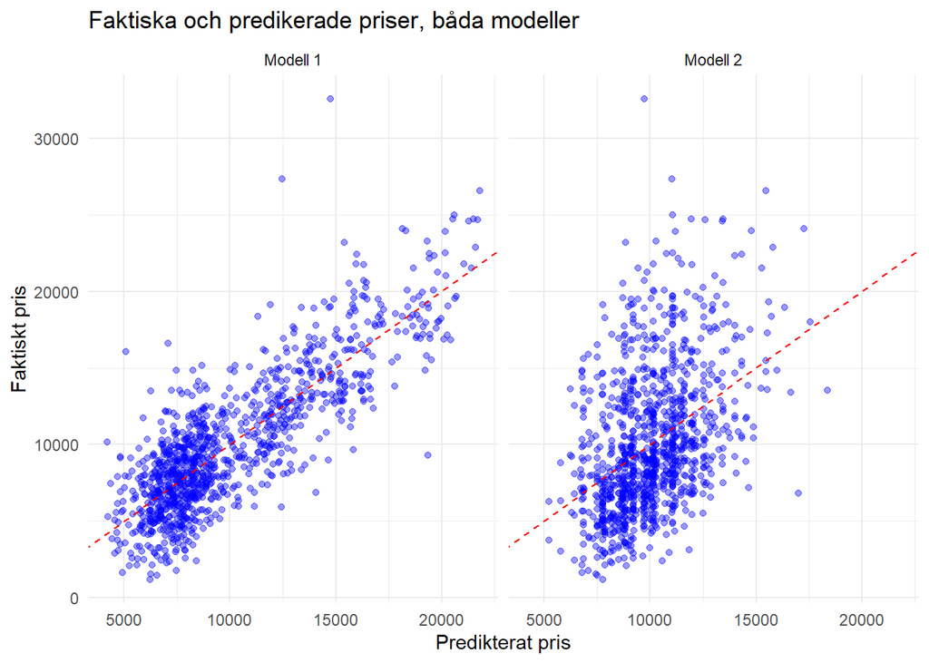

```r
# Gör regressions- och residualgrafer
source("script5_regression.R")

# 2 modellers faktiska och predikerade priser
regplot
```

Modell 1 visar mer närhet till *1:1 linjen*, medan modell 2 har större kluster under linjen.

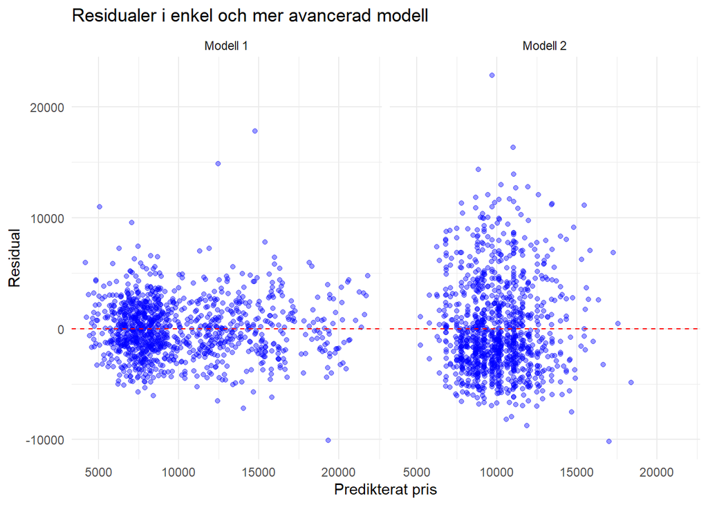

```r
# Residualgraf
errplot
```

Residualer ligger balanserat över och under 0-linjen för modell 1, medan modell 2 har större spridning av fel och kluster under linjen.

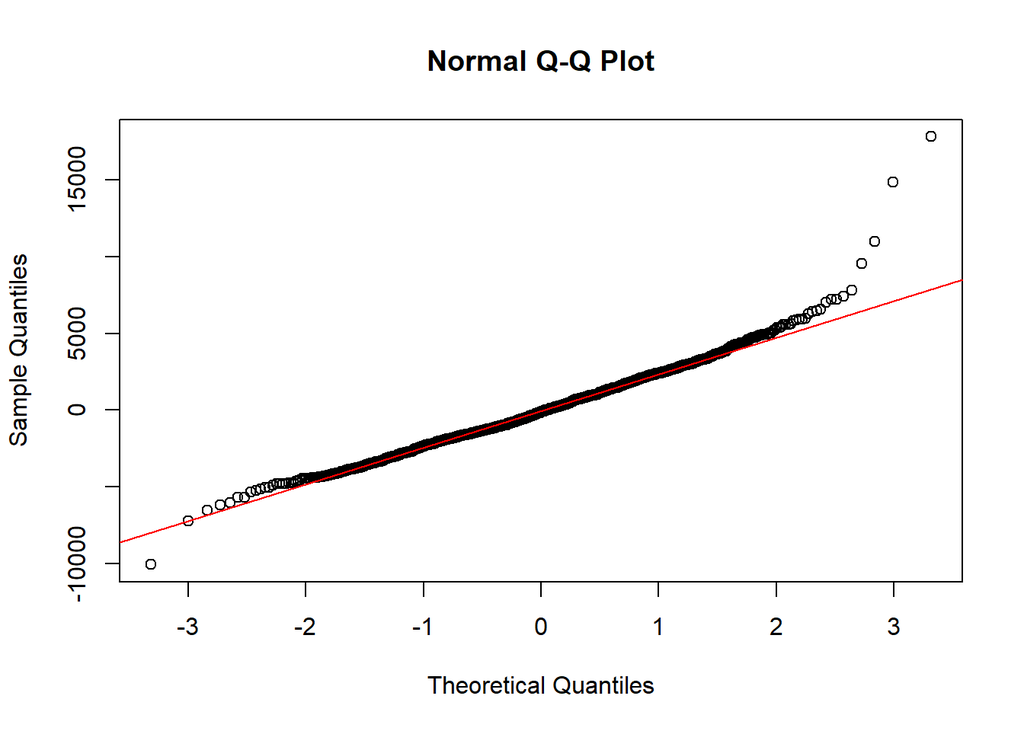

```r
# QQplot modell 1
qqnorm(resid(model1))
qqline(resid(model1), col = "red")
```

Första modellen har punkter nära referenslinjen för mestadelen, med lite flera uppgående outliers i höger.

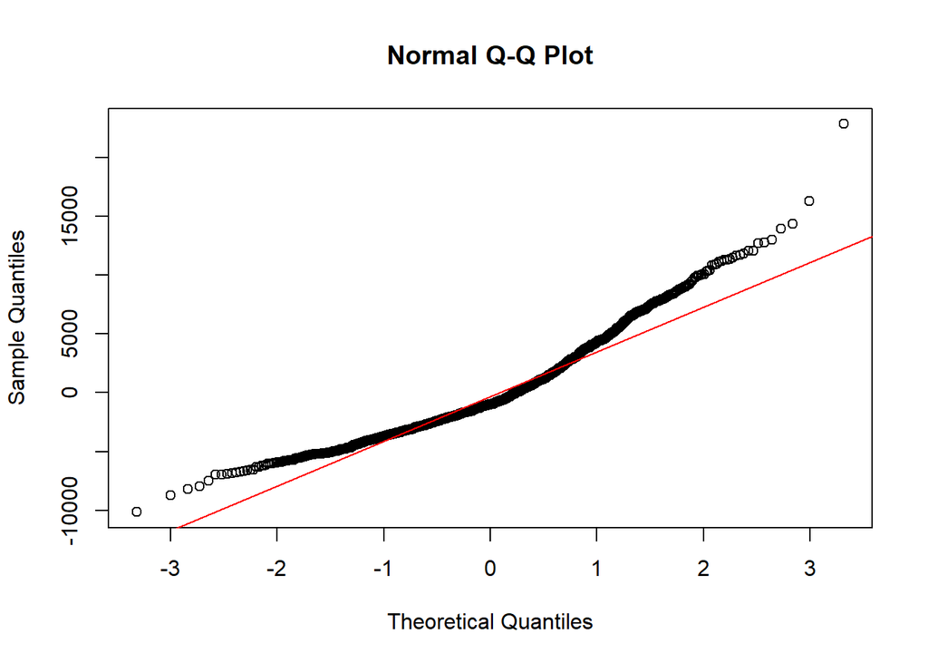

```r
# QQplot modell 2
qqnorm(resid(model2))
qqline(resid(model2), col = "red")
```

Andra modellen avviker mer från normalfördelning till vänster och höger med synlig skevhet.